# Analisis de datos epigenomicos

Renata Sandoval Chiw

2024-05-08

# Promotores vs enhancers putuativos

## Introducción

Los TFS (Transcription factors) son proteínas que activan o regulan un gen. Mientras que los promotores y enhancers son regiones del DNA en el que se llegan a unir dichos TFs. La unión de dichas proteínas con sus respectivos sitios promueve la regulación y activación de genes como anteriormente se mencionó. En este proyecto se espera conocer los TFs que estén enriquecidos en ambos set de secuencias utilizando diversas herramientas bioinformaticas y bases de datos, para la obtención de muestras y resultados. Este proyecto se ejecutó de manera similar al paper “Lineage-Specific Genome Architecture Links Enhancers and Non-coding Disease Variants to Target Gene Promoters”. Además de que se escogió el tipo celular debido a que en el paper los neutrofilos muestran un mayor enriquecimiento de promotores y enhancer a diferncia de otras células, y se escogió la H3K36m32 debido a que participa en la regulación de la respuespa al daño al DNA. Y su baja activación está ligada a baja eficiencia al reparar el DNA. Dichos mecanismos que considero interesantes.

## Procesos para obtener el bigwig desde los fastqc

Para los pasos de la obtención del bigwig se hara un enfoque general en lo que se esperaria que se hubiera realizado, dado que los datos provienen de ENCODE y no de blueprint. Solo se puede suponer cual fue el proceso. En este caso me guiare con el siguiente esquema.

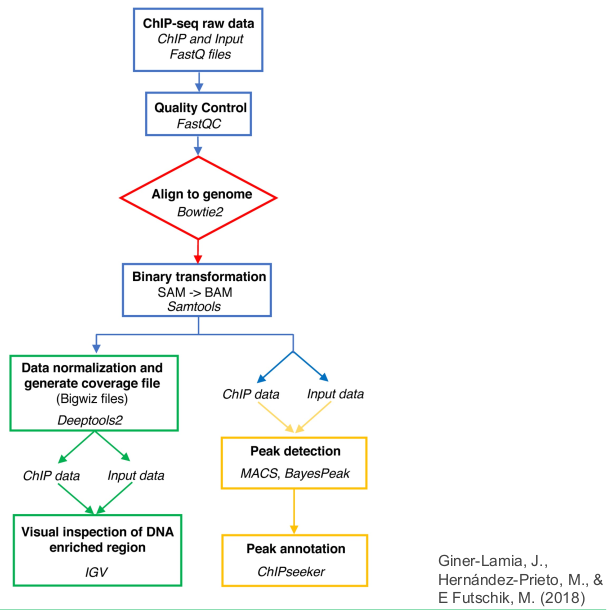

### Origen de los datos

Los datos provienen de ENCODE https://www.encodeproject.org/ especificamente de un experimento “Histone chip-seq” en neutrofilos. El siguiente link es del experimento en donde se obtuvieron los resultados (bigwig y bed) https://www.encodeproject.org/experiments/ENCSR072QBN/ .

Descarga de los datos con wget:

```r
# wget https://www.encodeproject.org/files/ENCFF461PAG/@@download/ENCFF461PAG.bed.gz
# wget https://www.encodeproject.org/files/ENCFF758UTV/@@download/ENCFF758UTV.bigWig
```

Los datos que se tomaron fueron alineados con el genoma 37, se hizo de esta manera debido a que en el paper se hace mención de alinear las muestras con el genoma 37 (hg19).

### Alineación con el genoma

Para el mapeo de los datos son necesarias las lecturas y un genoma de referencia, nuestro input son los archivos fastq y como resultado obtendriamos un sam. Puede realizarse con los programas Bowtie2, Bwa, Bowtie. El comando que supongo se ejecutaria para el mapeo sería el siguiente:

```r
# module load bwa/0.7.8
# bwa aln -t 8 genome_reference.fasta input.fastq > intermediate_file.sai
# bwa samse genome_reference.fasta intermediate_file.sai input.fastq > output.sam
```

Como anteriormente se había mencionado suponemos que se hace uso del genoma 37 como referencia.

### Pasos intermedios

En el paper se hace mención de filtrar ciertos **experimental artifacts** como lo son; **circularized reads y re-ligations**, ademas de remover las lecturas duplicadas.

### Bynary Transformation

El siguiente paso seria transformar el sam a un bam. Se usaría el siguiente comando:

```r
# samtools view -b output.sam > output.bam
```

Despues del bynary transformation parece que siguen dos procesos de los cuales uno es el **Peak detection** y otro **La obtención de los bigwig**.

### Peak detection

El peak calling genome that have been enriched with aligned reads as a consequence of performing a ChIP-sequencing experiment. El objetivo es identificar areas en el genoma que han sido enriquesidas depues de la alineacion, siendo estas obtenidas de experimentos chip-seq.Uno de estos programas que realiza el peak caller es MACS2. MACS2 ademas de identificar los picos que fueron enriquecidos, analiza la distribucion e intensidad a lo largo del genoma.

```r
# macs2 callpeak -t input.bam -n nombre_sin_extencion_para_el_output --outdir directorio_salida
```

Parte de los output es un archivo bed.El bed es un archivo que comunmente tiene información sobre regiones en el genoma como TFs binding sites, regiones de interés epigéneticas, etc. En este caso no fue necesario procesarlo ya que se descargó directamente de ENCODE.

### Obtención del archivo bigwig.

El bigwig es un tipo de archivo que tienen información sobre intensidad de la señal. El archivo bigwig fue descargado de ENCODE por lo que este proceso no se realizó. Para este proceso seguramente se empleo la herramienta **bamCoverage** la cual toma como input un archivo bam y puede generar un archivo bed o bigwig. El código que se podría emplear se vería de la siguiente manera:

```r
# bamCoverage -b input.bam -o output.bw
```

## Prueba estadistica para probar un mayor enriquecimiento de h3k36m3 en los promotores o enhancers

Utilizando las matrices generadas por compute matrix podemos realizar una prueba de wilcoxon la cual consiste en la compración de medianas de dos muestras. En este caso serían las medianas de los valores de la señal en enhancers y promotores.

La hipotesis nula sería que no existe una didfrencia, relacionandolo con que no hay un myor enriquecimiento en los promotores o enhancers. Contrariamente la Hipotesis alternativa mostraria que si hay una diferencia.

```r
##Generar vectores que contienen las medias de los valores de la señal en diferentes regiones del genoma
matr = read.table("/home/rschiw/Documents/Epi_project/matrix_enhancers_H3K36me3.tab", skip = 3)
matr.mean = vector()

##dado lo que aparece en el comando anterior parece ser que es a partir de V7 que estan los valores de la señal
##quitamos las primeras 6 columnas
matr <- matr[, -c(1, 2, 3, 4, 5, 6)]
for (i in 1:dim(matr)[1]) {
  matr.mean = append(matr.mean, mean(as.numeric(as.character(unlist(matr[i,]))),
                                 na.rm=TRUE), after = length(matr))

}

matr2 = read.table("/home/rschiw/Documents/Epi_project/matrix_promotores_H3K36me3.tab", skip = 3)
matr2.mean = vector()

##dado lo que aparece en el comando anterior parece ser que es a partir de V7 que estan los valores de la señal
matr2 <- matr2[, -c(1, 2, 3, 4, 5, 6)]
for (i in 1:dim(matr2)[1]) {
  matr2.mean = append(matr2.mean, mean(as.numeric(as.character(unlist(matr2[i,]))),
                                 na.rm=TRUE), after = length(matr2))

}

##Prueba de wilcoxon
result <- wilcox.test(matr.mean,matr2.mean, alternative="greater")
print(result)
```

```
##
##  Wilcoxon rank sum test with continuity correction
##
## data:  matr.mean and matr2.mean
## W = 4850166, p-value = 0.02376
## alternative hypothesis: true location shift is greater than 0
```

Dado el resultado de la prueba de Wilcoxon podríamos decir que rechazamos la hipotesis nula, por lo tanto si existe una diferencia en el enriquecimiento de promotres y enhncers. Dada la diferencia podríamos asumir que hay un mayor enriquecimiento en los enhancers

### Pasos para llegar a la compración de promotores y enhancers en la histona de interés.

Los siguientes comandos fueron ejecutados en R dentro del cluster.

1- Cargar el modulo y abrir la interfaz de r.

```r
# module load r/4.2.2
# R
```

2- El archivo de ActivePromoterEnhancerLinks.tsv fue obtenido de la información suplemetaria del paper. más especificamente dentro de “DATA_S1.zip”, en este archivo se encuentran los promoteres y enhancer presentes.

```r
# promenh <- read.table("ActivePromoterEnhancerLinks.tsv", header = T, sep = "\t")
# head(promenh)
#
# # a traves de esa tabla sigue obtener las coordenadas de los promotores, fragmentos
# library(GenomicRanges)
# coor_promotores <- makeGRangesFromDataFrame(promenh, keep.extra.columns = T,
#                                        start.field = "baitSt", end.field = "baitEnd",
#                                        seqnames.field = "baitChr", strand.field = "*")
#
# coor_enhancers <- makeGRangesFromDataFrame(promenh, keep.extra.columns = T,
#                                        start.field = "oeSt", end.field = "oeEnd",
#                                        seqnames.field = "oeChr", strand.field = "*")
# ##Finalmente exportamos las coordenadas en formato bed para tranajar con ellas en la terminal
# library(rtracklayer)
# export.bed(coor_promotores,con='promotores.bed')
# export.bed(coor_enhancers,con='enhancers.bed')
```

Después se trabaja con las coordenadas directamente en la terminal. Lo primero sería ejecutar el comando awk el cual nos permite eliminar las regiones repetidas.

```r
# awk '!x[$0]++' enhancers.bed > enhancersu.bed
# awk '!x[$0]++' promotores.bed > promotoresu.bed
```

Con estos archivos se buscan las regiones que estén tanto en los archivos provenientes de “” como en el bed el cual fue descargado de ENCODE. bedtools intersect identifica intersección entre dos archivos bed que contienen regiones de interes del genoma.

```r
# bedtools/2.26
# bedtools intersect -wa -a promotoresu.bed -b ENCFF461PAG.bed.gz | awk '!x[$0]++' > promotores_presentes.bed
# bedtools intersect -wa -a enhancersu.bed -b ENCFF461PAG.bed.gz | awk '!x[$0]++' > enhancers_presentes.bed
```

Teniendo las coordenadas de promotores y enhancers presentes podemos obtener una matriz de intensidad de señal en regiones específicas. computeMatrix scale-regions justamente hace eso y toma como input el archivo bigwig el cual fue obtenido de ENCODE y un archivo de anotación de regiones de interés (bed), dichas regiones se encuentran en los archivos promotores_presentes.bed y enhancers_presentes.bed

Con dichas matrices podemos generar un heatmap para los promotores y otro para los enhancers.

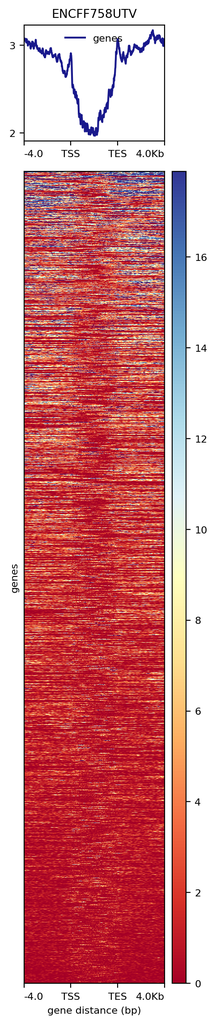

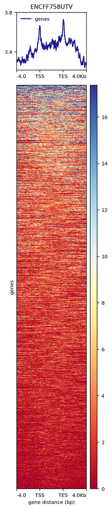

```r
# module load deeptools/2.5.3
# plotHeatmap -m matrix_promotores_H3K36me3.tab.gz -out H3K36me3_promotores.png --regionsLabel genes
# plotHeatmap -m matrix_enhancers_H3K36me3.tab.gz -out H3K36me3_enhancers.png --regionsLabel genes
```

## ¿Qué TFs se encuentran enriquecidos en ambos sets de secuencias?

El enriquecimiento de TFs es un proceso tardado, para fines del proyecto y ver su funcionamiento se observan los TFs del cromosoma 20. La razón de esto es simplemente por el tamaño del cromosoma, siendo que este abarca un 2.10% del total de DNA. Otra manera de optimizar este proceso podría ser usando el webserver que nos proporsiona rsat. Dado lo anterior se extraria de nuestros archivos promotores_presentes.bed yenhancers_presentes.be solo las coordenas que se encuentran en el cromosoma 20.

### Controles para el enriquecimiento de los TFs

**¿Qué es rsat?**

Regulatory Sequence Analysis Tools nos brinda diferentes herramienteas que sirven para identificar sitios de unión a factores de transcripción, regiones regulatorias etc.

**¿Qué hace matrix-scan?**

matrix-scan es una herramienta de RSAT que identidica posibles sitios de unión para TFs en regiones del genoma matrix-scan analiza una matriz TFBS (Transcriptional Factors Binding Sites) que se le da y busca coincidencias aproximadas en secuencias de DNA.

**Secuencias fasta**

matrix-scan necesita de secuencias de DNA en las cuales buscar coincidencias con la matriz TFBS, estas secuencias las generamos a partir de un fasta y las coordenadas de promotores y enhancers presentes. La herramienta bedtools extrae secuencias que han sido definidas por un archivo bed de un archivo fasta

```r
# bedtools getfasta -fi /mnt/Archives/genome/human/hg19/UCSC/samtools-index-0.1.19-sorted/hg19_sorted.fa -bed promotores_presentes_chr20.bed -fo promotores_seq_chr20.fa
#
# bedtools getfasta -fi /mnt/Archives/genome/human/hg19/UCSC/samtools-index-0.1.19-sorted/hg19_sorted.fa -bed enhancers_presentes_chr20.bed -fo enhancers_seq_chr20.fa
```

**Matriz no redundante de JASPAR**

La matriz no redundante de JASPAR es una TFBS, proveniente de experimentos de biología molecular. Al ser no redundante hace referencia a que se ha filtrado para eliminar redundancias. Dicho esto esta matriz de JASPAR nos da una colección mas eficiente de matrices, dado que se eliminan matrices parecidas para evitar la redundancia. Dicha matriz es obtenida de la base de datos de JASPAR. https://jaspar.elixir.no/downloads/

```r
# wget https://jaspar.elixir.no/download/data/2024/CORE/JASPAR2024_CORE_non-redundant_pfms_jaspar.txt
```

**Secuencias permutadas**

Las secuencias permutadas son secuencias generadas a partir de una secuencia original. Normalmente son utilizadas como controles para evaluar ciertos aspectos estadisticos.

```r
# random-seq  -template_format len -i promotores_seq_chr20.fa -format fasta -o secuenciaspermutadasp.fa
# random-seq  -template_format len -i enhancers_seq_chr20.fa -format fasta -o secuenciaspermutadase.fa
```

### Enriquecimientos de los TFs

Con los parametros establecidos y mencionados anteriormente se puede ejecutar el siguiente comando con los diferentes controles.

```r
# module load rsat/8sep2021.save
# matrix-scan -v 1 -matrix_format jaspar -m JASPAR2024_CORE_non-redundant_pfms_jaspar.txt -bginput -markov 1 -pseudo 1 -decimals 1 -2str -origin end -return distrib -return occ_proba -sort_distrib -uth occ_pval 1e-4  -lth occ_sig 0 -uth occ_sig_rank 1  -lth score 5 -i promotores_seq_chr20.fa -seq_format fasta -n skip -o mat_final_promotores2.tab
```

##Imagen de los resultados

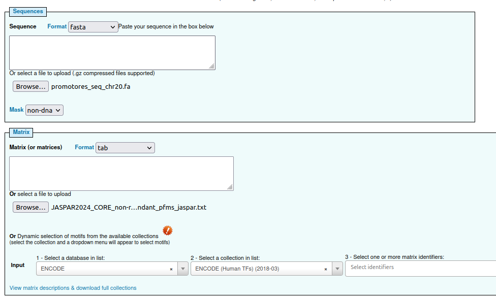

Lo que esperariamos obtener serían TFs que se encuentran en los promotores y enhancers.

[figure not shown]

[figure not shown]

### ¿Por qué me conviene usar la colección no redundante?

Dado que es no redundante puede simplificar el análisis y elevar la eficiencia que lleva a cabo matrix-scan.

### ¿Por qué usar secuencias permutadas me sirve como control?

Las secuencias permutadas nos permite comparar las frecuencias de unión entre los TFs y así aceptar o descartar a una secuenccia como sitio de unión específico para un TF.

## Conclusión

Dado los resultados obtenidos se pueden concluir diferentes cosas, la primera sería que hay una diferencia en el enriquecimiento de la H3K36m3 en enhancers y promotores dicha diferencia pudo ser probada estadisticamente por una prueba Wilcoxon, después sería que parece que está diferencia es debido a que la H3K36M3 se encuentra mayormente enriquecida en los enhancers.

### Bibliografía (incluyendo de los programas usados)

Sun, Z., Zhang, Y., Jia, J. et al. H3K36me3, message from chromatin to DNA damage repair. Cell Biosci 10, 9 (2020). https://doi.org/10.1186/s13578-020-0374-z

Biola M. Javierre, Oliver S. Burren, Steven P. Wilder, Roman Kreuzhuber, Steven M. Hill, Sven Sewitz, Jonathan Cairns, Steven W. Wingett, Csilla Várnai, Michiel J. Thiecke, Frances Burden, Samantha Farrow, Antony J. Cutler, Karola Rehnström, Kate Downes, Luigi Grassi, Myrto Kostadima, Paula Freire-Pritchett, Fan Wang, Joost H. Martens, Bowon Kim, Nilofar Sharifi, Eva M. Janssen-Megens, Marie-Laure Yaspo, Matthias Linser, Alexander Kovacsovics, Laura Clarke, David Richardson, Avik Datta, Paul Flicek, Hendrik G. Stunnenberg, John A. Todd, Daniel R. Zerbino, Oliver Stegle, Willem H. Ouwehand, Mattia Frontini, Chris Wallace, Mikhail Spivakov, Peter Fraser, Lineage-Specific Genome Architecture Links Enhancers and Non-coding Disease Variants to Target Gene Promoters, Cell, Volume 167, Issue 5, 2016, Pages 1369-1384.e19, ISSN 0092-8674, https://doi.org/10.1016/j.cell.2016.09.037. (https://www.sciencedirect.com/science/article/pii/S0092867416313228)

JASPAR, https://jaspar.elixir.no/downloads/

MACS2, https://chipster.csc.fi/manual/macs2.html

DEEPTOOLS, https://deeptools.readthedocs.io/en/develop/content/tools/bamCoverage.html

MACS2, https://chipster.csc.fi/manual/macs2.html https://hbctraining.github.io/Intro-to-ChIPseq/lessons/05_peak_calling_macs.html BEDTOOLS, https://bedtools.readthedocs.io/en/latest/content/tools/getfasta.html

**Programas**

bwa/0.7.8

samtools/1.9

deeptools/2.5.3

r/4.2.2

rsat/8sep2021.save

bedtools/2.26